# 3.5 PCA

## 3.5 PCA

- N 개의 M차원 데이터가 있으면 보통 그 데이터들은 서로 다른 값을 가진다. 하지만 이러한 데이터 간의 변이(variation)는 무작위가 아니라 특정한 규칙에 의해 만들어지는 경우가 있다. 예를 들어 붓꽃의 꽃받침 길이는 꽃마다 다르지만 꽃받침 길이가 약 2배 커지면 꽃받침 폭도 약 2배 커지는 것이 일반적이다. 이러한 데이터 간의 변이 규칙을 찾아낼 때 PCA를 이용할 수 있다.
- PCA(Principal Component Analysis)는 주성분 분석이라고도 하며 고차원 데이터 집합이 주어졌을 때 원래의 고차원 데이터와 가장 비슷하면서 더 낮은 차원 데이터를 찾아내는 방법이다. 차원축소(dimension reduction)라고도 한다. 더 낮은 차원의 데이터값 변화가 더 높은 차원의 데이터값 변화를 설명할 수 있다는 것은 얼핏 보기에 복잡해 보이는 고차원 데이터의 변이를 몇 가지 원인으로 설명할 수 있다는 뜻이다.
- 여기에서는 몇 가지 데이터에 대해 PCA가 사용되는 예를 보인다.

### 1. 붗꽃 데이터의 차원 축소

### 1) 사이킷런의 붓꽃 데이터 중, 10송이의 데이터(표본 10개)만 선택하여 꽃받침 길이와 꽃받침 폭 데이터를 그래프로 표현

```python
from sklearn.datasets import load_iris
```

```python
%matplotlib inline
```

```python
iris = load_iris()
```

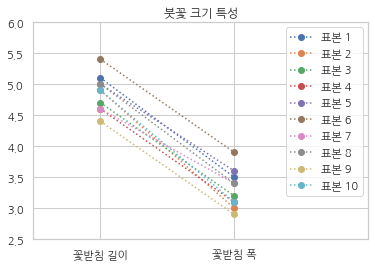

```python
N = 10 # 앞의 10송이만 선택
X = iris.data[:N, :2] #꽃받침 길이와 꽃받침 폭만 선택

plt.plot(X.T, "o:")
plt.xticks(range(4), ["꽃받침 길이", "꽃받침 폭"])
plt.xlim(-0.5, 2)
plt.ylim(2.5,6)
plt.title("붓꽃 크기 특성")
plt.legend(["표본 {}".format(i+1) for i in range(N)])
plt.show()
```

#### => 꽃받침 길이가 크면 꽃받침 폭도 같이 커진다는 규칙을 알 수 있다.

### 2) 가로축: 꽃받침 길이, 세로축: 꽃받침 폭으로 하는 scatter plot

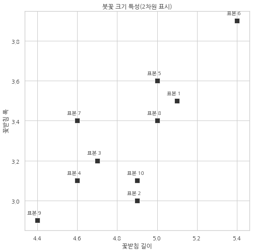

```python
plt.figure(figsize = (8,8))
ax = sns.scatterplot(0,1, data=pd.DataFrame(X), s=100, color = '.2', marker = 's')
for i in range(N):
    ax.text(X[i,0] - 0.05 , X[i,1] + 0.03 , '표본 {}'.format(i+1))
plt.xlabel("꽃받침 길이")
plt.ylabel("꽃받침 폭")
plt.title("붓꽃 크기 특성(2차원 표시)")
plt.axis("equal")
plt.show()
```

#### => 여기서도, 데이터를 나타내는 점들이 양의 기울기를 가지기 때문에 여기서도 마찬가지로 꽃받침의 길이가 크면 꽃받침의 폭도 같이 커진다는 규칙 확인

- (꽃받침 길이, 꽃받침 폭)이라는 2차원 측정 데이터는 사실 '꽃 크기'라는 근본적인 데이터가 두 가지 형태로 표현된 것에 지나지 않음.
- 이처럼, 측정되지는 않지만 측정된 데이터의 기저에 숨어서 측정 데이터를 결정짓는 데이터를 잠재변수(latent variable)라고 부른다.

#### PCA에서는 잠재변수와 측정데이터가 선형적인 관계로 연결되어 있다고 가정.

- 즉, i 번째 표본의 측정 데이터 벡터 xi 의 각 원소를 선형조합하면 그 뒤에 숨은 i 번째 표본의 잠재변수 ui 의 값을 계산할 수 있다고 가정.
- 붓꽃의 예에서는 꽃받침의 길이와 꽃받침 폭을 선형조합하여 꽃의 크기를 나타내는 어떤 값을 찾은 것이라고 할 수 있다.

### 2. 차원축소와 투영

- 차원축소문제는 다차원 벡터를 더 낮은 차원의 벡터공간에 투영하는 문제로 생각하여 풀 수 있다. 즉, 특이분해에서 살펴본 로우-랭크 근사(low-rank approximation) 문제가 된다. 이 문제는 다음과 같이 서술할 수 있다.
- N 개의 M차원 데이터 벡터 x1,x2,⋯,xN를 정규직교인 기저벡터 w1,w2,⋯,wK로 이루어진 K차원 벡터공간으로 투영하여 가장 비슷한 N개의 K차원 벡터 x∥w1,x∥w2,⋯,x∥wN를 만들기 위한 정규직교 기저벡터 w1,w2,⋯,wK를 찾는다.

### 3. 사이킷런의 PCA 기능

-사이킷런의 decomposition 서브패키지는 PCA 분석을 위한 PCA 클래스를 제공한다. 사용법은 다음과 같다.

#### 입력 인수:

- n_components : 정수

#### 메서드:

- fit_transform(): 특징 행렬을 낮은 차원의 근사 행렬로 변환
- inverse_transform(): 변환된 근사행렬을 원래의 차원으로 복귀

#### 속성:

- mean_: 평균 벡터
- components_ : 주성분 벡터

#### <붗꽃 데이터를 1차원으로 차원축소(근사)>

```python
from sklearn.decomposition import PCA
```

```python
pca1 = PCA(n_components=1)
X_low = pca1.fit_transform(X) # 1차원 근사 데이터 집합
X2=pca1.inverse_transform(X_low) # 다시 2차원으로 복귀한 근사 데이터의 집합
```

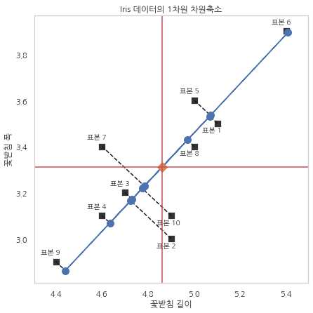

```python
plt.figure(figsize=(7,7))
ax = sns.scatterplot(0, 1, data=pd.DataFrame(X), s=100, color='.2', marker='s')
for i in range(N):
    d = 0.03 if X[i,1] > X2[i,1] else -0.04
    ax.text(X[i,0] - 0.065, X[i,1]+d, '표본 {}'.format(i+1))
    plt.plot([X[i,0], X2[i,0]], [X[i,1],X2[i,1]],'k--')
plt.plot(X2[:, 0], X2[:, 1], "o-", markersize=10)
plt.plot(X[:, 0].mean(), X[:, 1].mean(), markersize=10, marker="D")
plt.axvline(X[:, 0].mean(), c='r')
plt.axhline(X[:, 1].mean(), c='r')
plt.grid(False)
plt.xlabel("꽃받침 길이")
plt.ylabel("꽃받침 폭")
plt.title("Iris 데이터의 1차원 차원축소")
plt.axis("equal")
plt.show()
```

```python
pca1.mean_ # 데이터의 평균값 (붉은색 점)
```

```
array([4.86, 3.31])
```

```python
pca1.components_ # 주성분 벡터(가장 근사 데이터를 만드는 단위 기저벡터). 여기서는 파란색 기저벡터의 방향을 나타내는 단위 벡터.
```

```
array([[0.68305029, 0.73037134]])
```

#### => 주성분 벡터 값은 평균을 제거한 특징 행렬의 첫 번째 오른쪽 특이벡터 또는 그 행렬의 분산 행렬의 첫째(가장 큰 고윳값에 대응하는) 고유벡터에 해당한다. 고유벡터의 부호(방향)는 반대가 될 수도 있음.

```python
X0 = X - X.mean(axis = 0)
U, S, VT = np.linalg.svd(X0)
VT
```

```
array([[-0.68305029, -0.73037134],
       [-0.73037134,  0.68305029]])
```

```python
VT[:,0]
```

```
array([-0.68305029, -0.73037134])
```

#### ※ 고윳값 분해를 할때는 넘파이가 고윳값 순서에 따른 정렬을 해주지 않으므로, 사용자가 정렬해야 함.

```python
XCOV= X0.T@X0 # 분산행렬 형태
W, V = np.linalg.eig(XCOV)
```

```python
W
```

```
array([0.17107711, 1.44192289])
```

```python
V
```

```
array([[-0.73037134, -0.68305029],
       [ 0.68305029, -0.73037134]])
```

```python
V[:, np.argmax(W)]
```

```
array([-0.68305029, -0.73037134])
```

```python
X[7, :] # 8번째 꽃의 꽃받침 길이와 폭
```

```
array([5. , 3.4])
```

```python
X_low[7] # PCA로 구한 주성분의 값(꽃의 크기). 아래와 같이 구할수도 있음.
```

```
array([0.16136046])
```

```python
pca1.components_ @ (X[7,:] - pca1.mean_)
```

```
array([0.16136046])
```

```python
X2[7,:] # 다시 2차원 값으로 나타낸 근사값
```

```
array([4.97021731, 3.42785306])
```

### 4. 이미지 PCA (사람의 얼굴 데이터를 PCA로 분석)

```python
from sklearn.datasets import fetch_olivetti_faces
```

```python
faces_all = fetch_olivetti_faces()
K = 20 # 20번째 인물의 사진만 선택
faces = faces_all.images[faces_all.target == K]
```

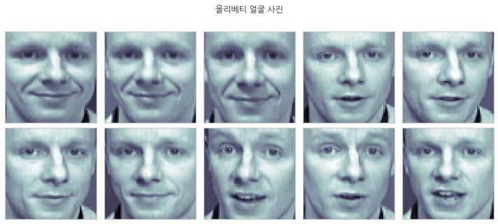

```python
N=2
M=5
fig = plt.figure(figsize = (10,5))
plt.subplots_adjust(top=1, bottom=0, hspace=0, wspace =0.05)
for i in range(N):
    for j in range(M):
        k = i * M + j
        ax = fig.add_subplot(N, M, k+1)
        ax.imshow(faces[k], cmap=plt.cm.bone)
        ax.grid(False)
        ax.xaxis.set_ticks([])
        ax.yaxis.set_ticks([])
plt.suptitle('올리베티 얼굴 사진')
plt.tight_layout()
plt.show()
```

```python
faces.shape # 4096차원
```

```
(10, 64, 64)
```

#### 4096차원을 2차원으로 축소(w1, w2)

- w1: 데이터가 가장 많이 변화하는 방향을 찾아줌
- w2: 그 다음으로 데이터가 가장 많이 변화하는 방향 찾아줌.

#### 이 사진을 주성분이 2개인 PCA 분석한 결과

```python
from sklearn.decomposition import PCA
pca3 = PCA(n_components = 2) #2차원으로 축소
X3 = faces_all.data[faces_all.target == K]
w3 = pca3.fit_transform(X3)
X32 = pca3.inverse_transform(w3) # 원래의 4096 차원으로 복귀
```

#### 주성분 분석으로 근사화한 이미지 표현

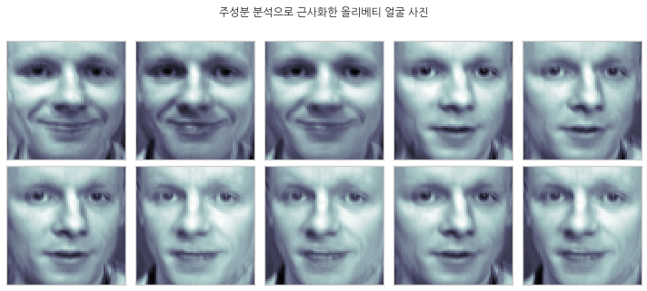

```python
N=2
M=5
fig = plt.figure(figsize = (10, 5))
plt.subplots_adjust(top=1, bottom=0, hspace=0, wspace=0.05)
for i in range(N):
    for j in range(M):
        k = i * M + j
        ax = fig.add_subplot(N, M, k+1)
        ax.imshow(X32[k].reshape(64,64), cmap = plt.cm.bone)
        ax.grid(False)
        ax.xaxis.set_ticks([])
        ax.yaxis.set_ticks([])
plt.suptitle('주성분 분석으로 근사화한 올리베티 얼굴 사진')
plt.tight_layout()
plt.show()
```

#### => 이 얼굴들은 모두 평균값과 2개의 주성분 얼굴의 각기 다른 선형 조합임.

- 평균값과 2개의 주성분이 나타내는 얼굴을 이미지로 표시하면 아래와 같음.
- 주성분이 나타내는 얼굴을 아이겐 페이스라고도 한다.

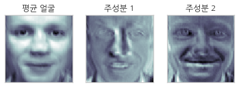

```python
face_mean = pca3.mean_.reshape(64,64) # 10개 이미지의 평균
face_p1 = pca3.components_[0].reshape(64,64)
face_p2 = pca3.components_[1].reshape(64,64)

plt.subplot(131)
plt.imshow(face_mean, cmap = plt.cm.bone)
plt.grid(False)
plt.xticks([])
plt.yticks([])
plt.title('평균 얼굴')
plt.subplot(132)
plt.imshow(face_p1, cmap = plt.cm.bone)
plt.grid(False)
plt.xticks([])
plt.yticks([])
plt.title('주성분 1') # 10개의 데이터가 어떻게 변화하고 있는지 방향을 나카내는 벡터
plt.subplot(133)
plt.imshow(face_p2, cmap = plt.cm.bone )
plt.grid(False)
plt.xticks([])
plt.yticks([])
plt.title('주성분 2') # 두번째 변화한 방향은 이렇게 변화했음을 나타냄.
plt.show()
```

#### 이 그림 만으로는 주성분 얼굴이 각각 어떤 의미를 가지는 지 알기 어려우므로, 평균 얼굴에 주성분 얼굴을 더한 모습 그리기

#### a) 평균 얼굴에 첫 번째 주성분 더하기

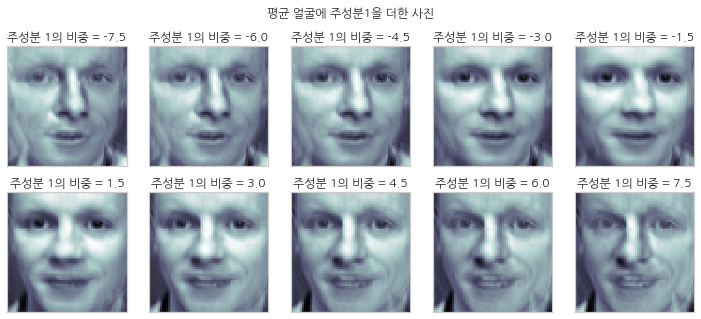

```python
N=2
M=5
fig = plt.figure(figsize = (10,5))
plt.subplots_adjust(top=1, bottom=0, hspace =0, wspace = 0.05)
for i in range(N):
    for j in range(M):
        k = i * M + j
        ax = fig.add_subplot(N, M, k+1)
        w = 1.5 * (k-5) if k<5 else 1.5 * (k-4)
        ax.imshow(face_mean + w * face_p1, cmap = plt.cm.bone)
        ax.grid(False)
        ax.xaxis.set_ticks([])
        ax.yaxis.set_ticks([])
        plt.title('주성분 1의 비중 = {}'.format(w))

plt.suptitle('평균 얼굴에 주성분1을 더한 사진')
plt.tight_layout()
plt.show()
```

#### => 첫 번째 주성분은 왼쪽과 오른쪽에서 바라본 얼굴 이미지의 차이를 나타냄을 알 수 있음.(고개의 방향이 달라짐)

#### b) 평균 얼굴에 두 번째 주성분 더하기

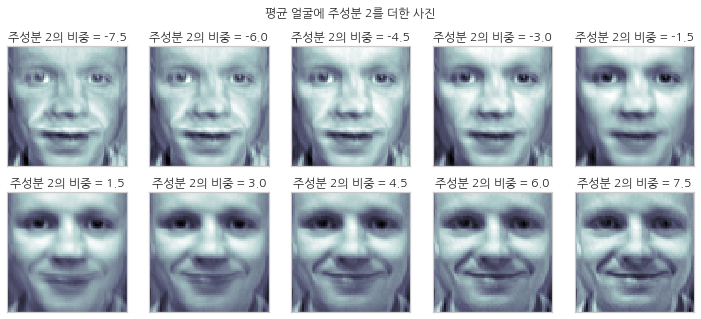

```python
N=2
M=5
fig = plt.figure(figsize=(10,5))
plt.subplots_adjust(top=1, bottom=0, hspace=0, wspace=0.05)
for i in range(N):
    for j in range(M):
        k = i * M + j
        ax = fig.add_subplot(N, M, k+1)
        w = 1.5 * (k-5) if k<5 else 1.5 * (k-4)
        ax.imshow(face_mean + w * face_p2, cmap = plt.cm.bone)
        ax.grid(False)
        ax.xaxis.set_ticks([])
        ax.yaxis.set_ticks([])
        plt.title('주성분 2의 비중 = {}'.format(w))

plt.suptitle('평균 얼굴에 주성분 2를 더한 사진')
plt.tight_layout()
plt.show()
```

#### => 두번째 주성분은 미소짓는 얼굴과 그렇지 않은 얼굴 이미지의 차이를 나타냄을 알 수 있음.

### 5. 주식 가격의 PCA

- 미국(US), 일본(JP), 유럽(EZ), 한국(KR)의 과거 20년간 주가

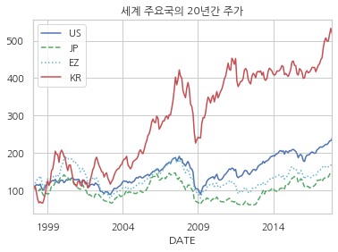

```python
pd.core.common.is_list_like = pd.api.types.is_list_like
import pandas_datareader.data as web
import datetime

symbols = [

    'SPASTT01USM661N', #US: 미국
    'SPASTT01JPM661N', #JP: 일본
    'SPASTT01EZM661N', #EZ: 유럽
    'SPASTT01KRM661N', #KR: 한국
]

data = pd.DataFrame()
for sym in symbols:
    data[sym] = web.DataReader(sym, data_source='fred',
                              start=datetime.datetime(1998, 1, 1),
                              end=datetime.datetime(2017,12,31))[sym]
data.columns = ['US', 'JP', 'EZ', 'KR']
data = data / data.iloc[0]*100 # 시작 시점의 주가 = 100

styles = ['-b', 'g--', 'c:', 'r-']
data.plot(style=styles)
plt.title('세계 주요국의 20년간 주가')
plt.show()
```

#### 연간 주식수익률 데이터

```python
df = ((data.pct_change() + 1).resample('A').prod() -1).T *100
print(df.iloc[:,:5])
```

```
DATE  1998-12-31  1999-12-31  2000-12-31  2001-12-31  2002-12-31
US     14.249290   10.800392    1.094171   -9.638213  -17.680773
JP     -8.567915   47.802619  -18.365577  -23.827406  -16.923968
EZ     21.308040   36.872314    1.375330  -21.857080  -30.647772
KR     10.411582   87.623876  -46.975114   27.644005    4.448180
```

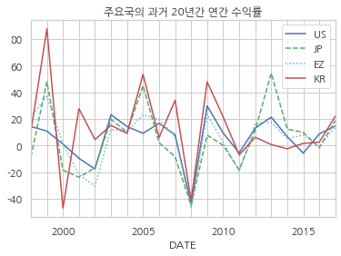

```python
df.T.plot(style=styles)
plt.title('주요국의 과거 20년간 연간 수익률')
plt.xticks(df.columns)
plt.show()
```

#### => 각 나라 수익률은 '경제적 요인'이라는 공통된 잠재 변수에 의해 결정됨

#### PCA 분석을 통해 모든 나라의 주가 움직임 기저에 깔려있는 성분 살펴보기

```python
pca2 = PCA(n_components=1)
w = pca2.fit_transform(df)
```

#### 세계 주가의 공통 요인은 평균값으로 구할 수 있다.

```python
m = pca2.mean_
```

#### 나라별로 주가를 다르게 하는 요인은 주성분으로 구할 수 있다.

```python
p1 = pca2.components_[0]
```

#### 평균 주가로부터 주성분이 더해질 수록 어떻게 주가의 형태가 변하는지 살펴보기.

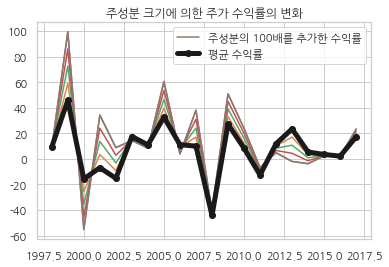

```python
xrange = np.linspace(1998, 2017, 20, dtype=int)
for i in np.linspace(0, 100, 5):
    plt.plot(xrange, pca2.mean_ + p1*i)
plt.plot(xrange, pca2.mean_ + p1 * 100, label = '주성분의 100배를 추가한 수익률')
plt.plot(xrange, pca2.mean_, 'ko-', lw=5, label = '평균 수익률')
plt.title('주성분 크기에 의한 주가 수익률의 변화')
plt.legend()
plt.show()
```

#### 이 주성분이 가지는 의미 살펴보기 위해 각 나라의 주성분 비중 구하기

```python
df_w = pd.DataFrame(w)
df_w.index = df.index
df_w.columns = ['주성분 비중']
print(df_w)
```

```
       주성분 비중
US -33.413784
JP -20.943197
EZ -26.917702
KR  81.274683
```

#### => 한국은 주성분이 80이 넘고, 나머지 국가들은 주성분의 성분이 음수임을 알 수 있음.

#### 주성분을 이용하여 구한 근사 주가

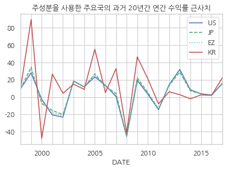

```python
df_i = pd.DataFrame(pca2.inverse_transform(w))
df_i.index = df.index
df_i.columns = df.columns
df_i.iloc[:, -10:]
df_i.T.plot(style=styles)
plt.title('주성분을 사용한 주요국의 과거 20년간 연간 수익률 근사치')
plt.xticks(df.columns)
plt.show()
```